# AnalysisBundeswahl2009

Duc-Anh Nguyen

2025-02-01

Read the dataset and check its features

```r
wahl <- read.table("Wahl.txt",header = TRUE)
head(wahl)
```

```
##   WA Geschlecht West    Alter_z Gewerk Abi Arbeitslos pol_Interesse
## 1  0          1    1 -28.511274      0   1          0             1
## 2  0          0    1  -8.511274      0   1          0             1
## 3  0          1    1  24.488726      0   0          0             1
## 4  1          1    1 -20.511274      0   0          0             1
## 5  0          1    1 -27.511274      0   0          1             1
## 6  0          1    1   3.488725      1   0          0             1
##   Demozufrieden Religion_kath Religion_Rest
## 1             0             0             0
## 2             1             0             0
## 3             1             0             0
## 4             1             0             0
## 5             1             0             1
## 6             1             0             1
```

```r
skimr::skim(wahl)
```

Data summary

| Name | wahl |
| --- | --- |
| Number of rows | 481 |
| Number of columns | 11 |
| _______________________ |  |
| Column type frequency: |  |
| numeric | 11 |
| ________________________ |  |
| Group variables | None |

**Variable type: numeric**

| skim_variable | n_missing | complete_rate | mean | sd | p0 | p25 | p50 | p75 | p100 | hist |
| --- | --- | --- | --- | --- | --- | --- | --- | --- | --- | --- |
| WA | 0 | 1 | 0.44 | 0.50 | 0.00 | 0.00 | 0.00 | 1.00 | 1.00 | ▇▁▁▁▆ |
| Geschlecht | 0 | 1 | 0.49 | 0.50 | 0.00 | 0.00 | 0.00 | 1.00 | 1.00 | ▇▁▁▁▇ |
| West | 0 | 1 | 0.73 | 0.44 | 0.00 | 0.00 | 1.00 | 1.00 | 1.00 | ▃▁▁▁▇ |
| Alter_z | 0 | 1 | 3.57 | 16.82 | -32.51 | -8.51 | 3.49 | 17.49 | 38.49 | ▃▇▇▇▃ |
| Gewerk | 0 | 1 | 0.14 | 0.35 | 0.00 | 0.00 | 0.00 | 0.00 | 1.00 | ▇▁▁▁▁ |
| Abi | 0 | 1 | 0.20 | 0.40 | 0.00 | 0.00 | 0.00 | 0.00 | 1.00 | ▇▁▁▁▂ |
| Arbeitslos | 0 | 1 | 0.04 | 0.19 | 0.00 | 0.00 | 0.00 | 0.00 | 1.00 | ▇▁▁▁▁ |
| pol_Interesse | 0 | 1 | 0.72 | 0.45 | 0.00 | 0.00 | 1.00 | 1.00 | 1.00 | ▃▁▁▁▇ |
| Demozufrieden | 0 | 1 | 0.53 | 0.50 | 0.00 | 0.00 | 1.00 | 1.00 | 1.00 | ▇▁▁▁▇ |
| Religion_kath | 0 | 1 | 0.38 | 0.48 | 0.00 | 0.00 | 0.00 | 1.00 | 1.00 | ▇▁▁▁▅ |
| Religion_Rest | 0 | 1 | 0.25 | 0.43 | 0.00 | 0.00 | 0.00 | 1.00 | 1.00 | ▇▁▁▁▃ |

```r
# fit a logit-model with interactions
logit_interaction_model <- glm(WA~.*., family = binomial(), data = wahl)
summary(logit_interaction_model)
```

```
##
## Call:
## glm(formula = WA ~ . * ., family = binomial(), data = wahl)
##
## Coefficients: (3 not defined because of singularities)
##                               Estimate Std. Error z value Pr(>|z|)
## (Intercept)                 -2.915e+00  1.116e+00  -2.611  0.00902 **
## Geschlecht                   9.869e-01  8.918e-01   1.107  0.26844
## West                         3.078e+00  9.785e-01   3.145  0.00166 **
## Alter_z                      4.049e-03  2.775e-02   0.146  0.88400
## Gewerk                       1.575e+00  1.255e+00   1.256  0.20926
## Abi                         -1.146e+00  1.156e+00  -0.991  0.32187
## Arbeitslos                   3.477e+01  1.905e+03   0.018  0.98543
## pol_Interesse                2.025e+00  9.356e-01   2.164  0.03043 *
## Demozufrieden                8.795e-01  8.586e-01   1.024  0.30563
## Religion_kath               -1.659e+01  6.394e+02  -0.026  0.97931
## Religion_Rest               -1.092e+00  1.031e+00  -1.060  0.28935
## Geschlecht:West             -1.805e+00  6.806e-01  -2.652  0.00800 **
## Geschlecht:Alter_z           4.074e-02  1.598e-02   2.549  0.01081 *
## Geschlecht:Gewerk           -6.792e-02  8.035e-01  -0.085  0.93263
## Geschlecht:Abi               7.701e-01  7.520e-01   1.024  0.30580
## Geschlecht:Arbeitslos        1.433e+00  1.422e+00   1.008  0.31332
## Geschlecht:pol_Interesse     2.542e-01  5.835e-01   0.436  0.66303
## Geschlecht:Demozufrieden     4.585e-01  4.953e-01   0.926  0.35467
## Geschlecht:Religion_kath    -3.228e-01  5.833e-01  -0.553  0.58002
## Geschlecht:Religion_Rest     9.841e-02  6.454e-01   0.152  0.87881
## West:Alter_z                -1.575e-02  2.072e-02  -0.760  0.44710
## West:Gewerk                 -1.550e-01  1.078e+00  -0.144  0.88571
## West:Abi                    -1.334e+00  7.997e-01  -1.669  0.09518 .
## West:Arbeitslos             -1.906e+01  1.134e+03  -0.017  0.98659
## West:pol_Interesse          -1.468e+00  7.744e-01  -1.895  0.05806 .
## West:Demozufrieden          -4.070e-01  6.794e-01  -0.599  0.54915
## West:Religion_kath           1.543e+01  6.394e+02   0.024  0.98075
## West:Religion_Rest           7.055e-01  6.377e-01   1.106  0.26861
## Alter_z:Gewerk              -4.560e-02  3.073e-02  -1.484  0.13783
## Alter_z:Abi                 -5.600e-02  2.340e-02  -2.393  0.01672 *
## Alter_z:Arbeitslos          -3.866e-02  7.653e-02  -0.505  0.61349
## Alter_z:pol_Interesse       -3.249e-03  1.873e-02  -0.173  0.86228
## Alter_z:Demozufrieden       -2.453e-02  1.468e-02  -1.671  0.09480 .
## Alter_z:Religion_kath        1.039e-02  1.753e-02   0.593  0.55330
```

[output cut: 17 more lines]

```
## pol_Interesse:Religion_kath -3.013e-01  6.648e-01  -0.453  0.65034
## pol_Interesse:Religion_Rest -2.248e-01  7.372e-01  -0.305  0.76046
## Demozufrieden:Religion_kath  1.220e+00  5.594e-01   2.181  0.02922 *
## Demozufrieden:Religion_Rest  4.979e-01  6.702e-01   0.743  0.45753
## Religion_kath:Religion_Rest         NA         NA      NA       NA
## ---
## Signif. codes:  0 '***' 0.001 '**' 0.01 '*' 0.05 '.' 0.1 ' ' 1
##
## (Dispersion parameter for binomial family taken to be 1)
##
##     Null deviance: 659.55  on 480  degrees of freedom
## Residual deviance: 537.64  on 428  degrees of freedom
## AIC: 643.64
##
## Number of Fisher Scoring iterations: 15
```

Not many stat. significant effects. I want to check for colinearity now.

## Check for colinearity

We check for colinearity by checking for singularity in the design matrix

```r
X <- model.matrix(logit_interaction_model)
Matrix::rankMatrix(X)
```

```
## [1] 53
## attr(,"method")
## [1] "tolNorm2"
## attr(,"useGrad")
## [1] FALSE
## attr(,"tol")
## [1] 1.068035e-13
```

```r
dim(X)
```

```
## [1] 481  56
```

```r
logit_BIC_model <- MASS::stepAIC(object = logit_interaction_model, direction = "both", k = log(nrow(wahl)), trace = FALSE)
summary(logit_BIC_model)
```

```
##
## Call:
## glm(formula = WA ~ Geschlecht + West + Alter_z + Gewerk + Demozufrieden +
##     Religion_kath + Religion_Rest + Geschlecht:West + Alter_z:Religion_Rest,
##     family = binomial(), data = wahl)
##
## Coefficients:
##                        Estimate Std. Error z value Pr(>|z|)
## (Intercept)           -1.548255   0.344650  -4.492 7.05e-06 ***
## Geschlecht             0.949003   0.400208   2.371 0.017727 *
## West                   1.439264   0.357346   4.028 5.63e-05 ***
## Alter_z               -0.001313   0.006659  -0.197 0.843646
## Gewerk                 1.017919   0.296164   3.437 0.000588 ***
## Demozufrieden          0.635902   0.200215   3.176 0.001493 **
## Religion_kath         -0.666172   0.234050  -2.846 0.004423 **
## Religion_Rest         -0.104982   0.265939  -0.395 0.693019
## Geschlecht:West       -1.233250   0.464684  -2.654 0.007956 **
## Alter_z:Religion_Rest -0.051298   0.015507  -3.308 0.000939 ***
## ---
## Signif. codes:  0 '***' 0.001 '**' 0.01 '*' 0.05 '.' 0.1 ' ' 1
##
## (Dispersion parameter for binomial family taken to be 1)
##
##     Null deviance: 659.55  on 480  degrees of freedom
## Residual deviance: 604.54  on 471  degrees of freedom
## AIC: 624.54
##
## Number of Fisher Scoring iterations: 4
```

There are only 7 main effects and 2 interaction effects left, one for sex:living(west or east) and one for age:religion(not catholic).

For main effects: age, being catholic, and following other religions are having a negative correlation with decision of voting for SPD instead of CCU.

The interaction of sex:living in the west and age:being religious are showing negative effects on the chance of voting for SPD instead of CCU

Now we will consider the non-linear effect of Alter_z (age). We fit the age effect and the interaction of age:sex now non-linearly with P-splines with max. number of nodes of k = 30

```r
logit_GAM_model <- mgcv::gam(formula = WA~s(Alter_z, bs = "ps", k = 30) + s(Alter_z, bs = "ps", k = 30, by = Geschlecht) + Geschlecht + West + Gewerk + Demozufrieden + Religion_kath  + Geschlecht*West, family = binomial(), data = wahl)

summary(logit_GAM_model)
```

```
##
## Family: binomial
## Link function: logit
##
## Formula:
## WA ~ s(Alter_z, bs = "ps", k = 30) + s(Alter_z, bs = "ps", k = 30,
##     by = Geschlecht) + Geschlecht + West + Gewerk + Demozufrieden +
##     Religion_kath + Geschlecht * West
##
## Parametric coefficients:
##                 Estimate Std. Error z value Pr(>|z|)
## (Intercept)      -1.5617     0.3207  -4.869 1.12e-06 ***
## Geschlecht        1.1277     0.4376   2.577 0.009963 **
## West              1.4743     0.3561   4.140 3.47e-05 ***
## Gewerk            1.0339     0.3042   3.399 0.000676 ***
## Demozufrieden     0.5820     0.1996   2.916 0.003544 **
## Religion_kath    -0.6169     0.2202  -2.801 0.005094 **
## Geschlecht:West  -1.1751     0.4633  -2.537 0.011195 *
## ---
## Signif. codes:  0 '***' 0.001 '**' 0.01 '*' 0.05 '.' 0.1 ' ' 1
##
## Approximate significance of smooth terms:
##                         edf Ref.df Chi.sq p-value
## s(Alter_z)            5.283  6.553 11.179  0.1042
## s(Alter_z):Geschlecht 1.000  1.001  3.526  0.0605 .
## ---
## Signif. codes:  0 '***' 0.001 '**' 0.01 '*' 0.05 '.' 0.1 ' ' 1
##
## Rank: 65/66
## R-sq.(adj) =  0.0803   Deviance explained = 8.06%
## UBRE = 0.31594  Scale est. = 1         n = 481
```

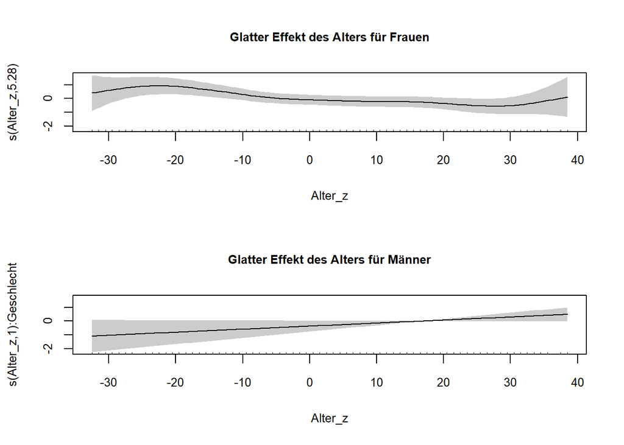

```r
# visualising the P-splines
par(mfrow = c(2,1))
plot(x = logit_GAM_model, shade = TRUE, select = 1, cex.main = 0.8, cex = 0.8, cex.lab = 0.8, cex.axis = 0.8, main = "Glatter Effekt des Alters für Frauen")
plot(x = logit_GAM_model, shade = TRUE, select = 2, cex.main = 0.8, cex = 0.8, cex.lab = 0.8, cex.axis = 0.8, main = "Glatter Effekt des Alters für Männer")
```

Attention: Although the lower graphic shows a linear effect for male voters, we need to add the effect of both plots in order to interpret the varying effect for males while simutaniously considering effect of age

## Evaluation with ROC

```r
library(tidyverse)
```

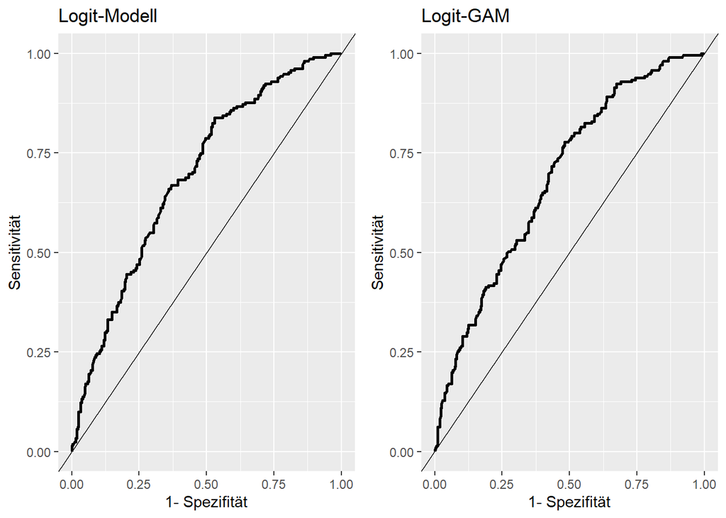

```r
library(ggplot2)
# install.packages("plotROC")  # Install (if not installed)
library(plotROC)  # Load the package
# install.packages("gridExtra")  # Install the package (if not installed)
library(gridExtra)  # Load the package
# Logit-Model:
wahl$BIC_predict <-
  predict(object = logit_BIC_model, type = "response")

plot1 <-
  ggplot(mapping = aes(m = BIC_predict, d = WA), data = wahl) + geom_roc(n.cuts = 0) + geom_abline(intercept = 0, slope = 1) + ylab("Sensitivität") + xlab("1- Spezifität") + theme() + ggtitle("Logit-Modell")

wahl$GAM_predict <-
  predict(object = logit_GAM_model, type = "response")

plot2 <-
  ggplot(mapping = aes(m = GAM_predict, d = WA), data = wahl) +
  geom_roc(n.cuts = 0) + geom_abline(intercept = 0, slope = 1) +
  ylab("Sensitivität") + xlab("1- Spezifität") + theme() +
  ggtitle("Logit-GAM")

# Gemeinsame Visualisierung
grid.arrange(plot1, plot2, ncol = 2)
```

getting the AUC

```r
library(pROC)
# logit_model
auc_logit_BIC <- roc(response = as.factor(wahl$WA), predictor = wahl$BIC_predict)$auc
auc_logit_GAM <- roc(response = as.factor(wahl$WA), predictor = wahl$GAM_predict)$auc
auc_logit_BIC
```

```
## Area under the curve: 0.6918
```

```r
auc_logit_GAM
```

```
## Area under the curve: 0.6866
```

does not make much of a different w.r.t. AUC

## Prediction:

now let us try to predict the chance of: + an catholic woman in her 25 in union from east germany, who is satisfied with democracy system in germany choosing SPD + a jewish man in his 75 not in union from west germany, who is not satisfied with democracy system

```r
newdata <-
  data.frame(
    Alter_z = c(-25.5, 24.5),
    Geschlecht = c(0, 1),
    West = c(0, 1),
    Gewerk = c(1, 0),
    Demozufrieden = c(1, 0),
    Religion_kath = c(1, 0),
    Religion_Rest = c(0, 1)
  )
newdata
```

```
##   Alter_z Geschlecht West Gewerk Demozufrieden Religion_kath Religion_Rest
## 1   -25.5          0    0      1             1             1             0
## 2    24.5          1    1      0             0             0             1
```

```r
# glm
predict(object = logit_BIC_model, newdata = newdata, type = "response")
```

```
##         1         2
## 0.3711902 0.1434161
```

```r
# gam
mgcv::predict.gam(object = logit_GAM_model, newdata = newdata, type = "response")
```

```
##         1         2
## 0.5764977 0.3866069
```